# 01u - G4mer rG4 features by mRNA region and association with eIF3d hypoxia TE (1hr)

Kate

2026-07-28

# Overview

Ingest G4mer RNA G-quadruplex predictions for all three mRNA regions and test whether rG4 propensity is associated with eIF3d-dependent translation efficiency in hypoxia at 1hr.

G4mer (`Biociphers/g4mer`, fine-tuned from mRNAbert) accepts a maximum of 70 nt per input and is 6-mer tokenized. Sequences are scanned with a 70 nt sliding window and collapsed to a per-transcript maximum, the aggregation the model authors recommend. Scores come from `g4mer/02_run_g4mer.py`; transcript selection is `precomputed_most_abundant_tx.rds`, the same universe as the ViennaRNA structure features.

**Two confounds are controlled throughout:**

1. *Length.* A maximum over more windows has a higher expected value, so `g4mer_max` rises with region length by construction.
2. *Composition.* rG4 formation requires G-runs, so the score necessarily tracks GC and G content.

Every association is reported raw and after residualizing on log2 region length and region GC%.

**Stride differs by region:** the 5’UTR was scored locally at stride 10, CDS and 3’UTR on the cluster at stride 20. Denser sampling raises the expected maximum, so for cross-region comparison the 5’UTR maximum is recomputed at stride 20 from the saved per-window scores. Within-region results are unaffected (Spearman between the two 5’UTR strides is 0.985).

Contrast direction (MDA-MB-231 convention): positive `te_lfc` = eIF3d **promotes**.

# Load Libraries

```r
library(tidyverse)
library(here)

set.seed(9)
```

```r
group_colors <- c(
  "eIF3d hypoxia promotes" = "#E69F00",
  "Negative control"       = "grey40",
  "All other genes"        = "grey80"
)

region_labels <- c(utr5 = "5'UTR", cds = "CDS", utr3 = "3'UTR")
regions <- c("utr5", "cds", "utr3")
```

# Load G4mer Scores

```r
g4_dir <- here("output", "g4mer")

load_region <- function(region) {
  summary_path <- file.path(g4_dir, paste0("g4mer_summary_", region, ".tsv"))
  meta_path    <- here("g4mer", "fasta", paste0(region, "_seq_metadata.tsv"))

  stopifnot(
    "G4mer summary not found - run g4mer/02_run_g4mer.py" = file.exists(summary_path),
    "sequence metadata not found - run g4mer/01_generate_fasta.R" = file.exists(meta_path)
  )

  scores <- read_tsv(summary_path, show_col_types = FALSE)
  meta   <- read_tsv(meta_path, show_col_types = FALSE)

  # --- Computational validation, applied identically to every region ---
  expected_cols <- c("transcript_id_clean", "region", "region_length", "n_windows",
                     "g4mer_max", "g4mer_mean", "g4mer_frac_above", "g4mer_argmax_start")
  stopifnot(all(expected_cols %in% colnames(scores)))

  stopifnot("g4mer_max outside [0,1]" =
    all(scores$g4mer_max >= 0 & scores$g4mer_max <= 1, na.rm = TRUE))
  stopifnot("g4mer_mean outside [0,1]" =
    all(scores$g4mer_mean >= 0 & scores$g4mer_mean <= 1, na.rm = TRUE))
  stopifnot("g4mer_frac_above outside [0,1]" =
    all(scores$g4mer_frac_above >= 0 & scores$g4mer_frac_above <= 1, na.rm = TRUE))
  stopifnot("g4mer_max < g4mer_mean" = all(scores$g4mer_max >= scores$g4mer_mean))
  stopifnot("n_windows < 1" = all(scores$n_windows >= 1))
  stopifnot("argmax_start out of bounds" =
    all(scores$g4mer_argmax_start >= 0 &
        scores$g4mer_argmax_start < scores$region_length))
  stopifnot("region column mislabeled" = all(scores$region == region))

  # Region lengths must agree with what was written to FASTA
  chk <- scores %>%
    dplyr::select(transcript_id_clean, region_length) %>%
    inner_join(meta %>% dplyr::select(transcript_id_clean, meta_len = region_length),
               by = "transcript_id_clean")
  stopifnot("region_length disagrees with FASTA metadata" =
    all(chk$region_length == chk$meta_len))
  stopifnot("scored transcripts missing from metadata" = nrow(chk) == nrow(scores))

  scores %>%
    inner_join(meta %>% dplyr::select(transcript_id_clean, gene_id_clean, symbol,
                                      gc_pct, g_pct),
               by = "transcript_id_clean")
}

g4_all <- map_dfr(regions, load_region)

g4_all %>%
  group_by(region) %>%
  summarise(
    n              = dplyr::n(),
    median_length  = median(region_length),
    median_windows = median(n_windows),
    median_max     = median(g4mer_max),
    median_gc      = median(gc_pct),
    .groups = "drop"
  ) %>%
  mutate(region = region_labels[region]) %>%
  print()
```

```
## # A tibble: 3 × 6
##   region     n median_length median_windows median_max median_gc
##   <chr>  <int>         <dbl>          <dbl>      <dbl>     <dbl>
## 1 CDS    10025          1227             59      0.227      51.4
## 2 3'UTR   9697           763             36      0.205      41.5
## 3 5'UTR   9545           129              7      0.189      66.1
```

```r
cat("\nAll computational checks passed for all three regions.\n")
```

```
##
## All computational checks passed for all three regions.
```

## Biological Spot-Check

Transcripts whose region contains a canonical G4 motif (four G-runs of >= 3 separated by 1-7 nt loops) must score higher than those without, in every region. This tests that the model output tracks G4 sequence grammar, catching a strand, tokenization, or window-indexing error that a range check cannot.

```r
read_fasta_tbl <- function(region) {
  fa <- here("g4mer", "fasta", paste0(region, "_sequences.fa"))
  stopifnot("FASTA not found" = file.exists(fa))
  lines <- read_lines(fa)
  hdr   <- which(str_starts(lines, ">"))
  ends  <- c(hdr[-1] - 1, length(lines))
  tibble(
    transcript_id_clean = word(str_remove(lines[hdr], "^>"), 1),
    region              = region,
    # writeXStringSet wraps sequence lines, so collapse the block under each header
    sequence            = map2_chr(hdr + 1, ends, ~ str_c(lines[.x:.y], collapse = ""))
  )
}

g4_regex <- "([Gg]{3,}[ACGTNacgtn]{1,7}){3,}[Gg]{3,}"

motif_tbl <- map_dfr(regions, read_fasta_tbl) %>%
  mutate(has_g4_motif = str_detect(sequence, g4_regex)) %>%
  dplyr::select(transcript_id_clean, region, has_g4_motif)

spot <- g4_all %>% inner_join(motif_tbl, by = c("transcript_id_clean", "region"))

motif_summary <- spot %>%
  group_by(region) %>%
  summarise(
    n_motif      = sum(has_g4_motif),
    pct_motif    = 100 * mean(has_g4_motif),
    med_motif    = median(g4mer_max[has_g4_motif]),
    med_no_motif = median(g4mer_max[!has_g4_motif]),
    wilcox_p     = wilcox.test(g4mer_max ~ has_g4_motif)$p.value,
    .groups = "drop"
  )
print(motif_summary %>% mutate(region = region_labels[region]))
```

```
## # A tibble: 3 × 6
##   region n_motif pct_motif med_motif med_no_motif  wilcox_p
##   <chr>    <int>     <dbl>     <dbl>        <dbl>     <dbl>
## 1 CDS        503      5.02     0.983        0.185 6.52e-189
## 2 3'UTR     1096     11.3      0.989        0.148 0
## 3 5'UTR      606      6.35     0.987        0.154 1.54e-249
```

```r
stopifnot("motif-containing regions do not score above motif-free ones" =
  all(motif_summary$med_motif > motif_summary$med_no_motif))
cat("\nBiological spot-check passed in all three regions.\n")
```

```
##
## Biological spot-check passed in all three regions.
```

# Harmonize Stride Across Regions

```r
# 5'UTR was scored at stride 10, CDS/3'UTR at stride 20. Recompute the 5'UTR maximum
# on the stride-20 subset of windows so cross-region comparisons are like-for-like.
utr5_windows <- read_tsv(file.path(g4_dir, "g4mer_windows_utr5.tsv.gz"),
                         show_col_types = FALSE)

utr5_s20 <- utr5_windows %>%
  filter(window_start %% 20 == 0) %>%
  group_by(transcript_id_clean) %>%
  summarise(g4mer_max_harmonized = max(g4_prob), .groups = "drop")

g4_all <- g4_all %>%
  left_join(utr5_s20, by = "transcript_id_clean") %>%
  mutate(g4mer_max_harmonized = if_else(region == "utr5",
                                        g4mer_max_harmonized, g4mer_max))

stopifnot("harmonized max missing" = all(!is.na(g4_all$g4mer_max_harmonized)))
stopifnot("harmonized max exceeds raw max" =
  all(g4_all$g4mer_max_harmonized <= g4_all$g4mer_max + 1e-9))

cat("5'UTR median max: stride 10 =",
    round(median(g4_all$g4mer_max[g4_all$region == "utr5"]), 4),
    "| stride 20 =",
    round(median(g4_all$g4mer_max_harmonized[g4_all$region == "utr5"]), 4), "\n")
```

```
## 5'UTR median max: stride 10 = 0.1886 | stride 20 = 0.1516
```

# Build Feature Table

```r
g4_features <- g4_all %>%
  mutate(log2_region_length = log2(region_length)) %>%
  dplyr::select(transcript_id_clean, gene_id_clean, symbol, region,
                g4mer_max, g4mer_max_harmonized, g4mer_mean, g4mer_frac_above,
                region_length, log2_region_length, gc_pct, g_pct) %>%
  pivot_wider(
    id_cols     = c(transcript_id_clean, gene_id_clean, symbol),
    names_from  = region,
    values_from = c(g4mer_max, g4mer_max_harmonized, g4mer_mean, g4mer_frac_above,
                    region_length, log2_region_length, gc_pct, g_pct),
    names_glue  = "{.value}_{region}"
  )

# Leakage guard: no TE column may enter the saved feature table
stopifnot("TE column leaked into feature table" =
  !any(str_detect(colnames(g4_features), "^te_")))

cat("Feature table:", nrow(g4_features), "transcripts,",
    ncol(g4_features), "columns\n")
```

```
## Feature table: 10025 transcripts, 27 columns
```

```r
saveRDS(g4_features, here("output", "predictive_modeling", "feature_matrix_g4mer.rds"))
cat("Saved: output/predictive_modeling/feature_matrix_g4mer.rds\n")
```

```
## Saved: output/predictive_modeling/feature_matrix_g4mer.rds
```

# Association with eIF3d Hypoxia TE (1hr)

```r
te_hyp <- read_csv(
  here("output", "translation_categories_si3d_vs_sictrl_hypoxia_1hr.csv"),
  show_col_types = FALSE
) %>%
  mutate(gene_id_clean = sub("\\..*", "", gene_id))

cat("TE genes (si3d vs sictrl, hypoxia 1hr):", nrow(te_hyp), "\n")
```

```
## TE genes (si3d vs sictrl, hypoxia 1hr): 11879
```

```r
# Positive te_lfc = sictrl TE > si3d TE = knockdown reduces TE = eIF3d promotes
dat_long <- g4_all %>%
  inner_join(te_hyp %>% dplyr::select(gene_id_clean, te_lfc, te_padj),
             by = "gene_id_clean") %>%
  filter(!is.na(te_lfc)) %>%
  mutate(log2_region_length = log2(region_length))

dat_long %>%
  group_by(region) %>%
  summarise(n_genes = dplyr::n(), .groups = "drop") %>%
  mutate(region = region_labels[region]) %>%
  print()
```

```
## # A tibble: 3 × 2
##   region n_genes
##   <chr>    <int>
## 1 CDS      10025
## 2 3'UTR     9697
## 3 5'UTR     9545
```

## Per-Region Correlation, Raw and Length/GC-Controlled

```r
region_stats <- dat_long %>%
  group_by(region) %>%
  group_modify(function(d, key) {
    raw <- suppressWarnings(cor.test(d$g4mer_max, d$te_lfc, method = "spearman"))

    # Residualize both variables on log2 length and GC to isolate the
    # rG4-specific component
    r_g4 <- residuals(lm(g4mer_max ~ log2_region_length + gc_pct, data = d))
    r_te <- residuals(lm(te_lfc ~ log2_region_length + gc_pct, data = d))
    par  <- suppressWarnings(cor.test(r_g4, r_te, method = "spearman"))

    tibble(
      n            = nrow(d),
      rho_raw      = raw$estimate,
      p_raw        = raw$p.value,
      rho_partial  = par$estimate,
      p_partial    = par$p.value,
      rho_len_te   = cor(d$log2_region_length, d$te_lfc, method = "spearman"),
      rho_gc_te    = cor(d$gc_pct, d$te_lfc, method = "spearman"),
      rho_len_g4   = cor(d$log2_region_length, d$g4mer_max, method = "spearman")
    )
  }) %>%
  ungroup()

region_stats %>%
  mutate(region = region_labels[region]) %>%
  mutate(across(starts_with("rho"), ~ round(.x, 4)),
         across(starts_with("p_"), ~ format.pval(.x, digits = 3))) %>%
  print(width = Inf)
```

```
## # A tibble: 3 × 9
##   region     n rho_raw p_raw  rho_partial p_partial rho_len_te rho_gc_te
##   <chr>  <int>   <dbl> <chr>        <dbl> <chr>          <dbl>     <dbl>
## 1 CDS    10025 -0.221  <2e-16     -0.0056 0.57674      -0.158     -0.362
## 2 3'UTR   9697 -0.155  <2e-16     -0.0166 0.10217      -0.088     -0.264
## 3 5'UTR   9545  0.0174 0.0888      0.0319 0.00184       0.0579    -0.151
##   rho_len_g4
##        <dbl>
## 1      0.412
## 2      0.636
## 3      0.460
```

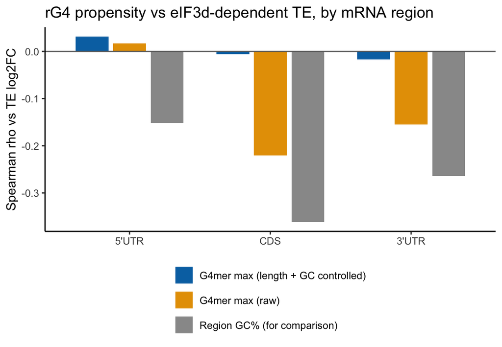

```r
rho_plot_df <- region_stats %>%
  dplyr::select(region, rho_raw, rho_partial, rho_gc_te) %>%
  pivot_longer(-region, names_to = "measure", values_to = "rho") %>%
  mutate(
    region  = factor(region_labels[region], levels = region_labels),
    measure = recode(measure,
                     rho_raw     = "G4mer max (raw)",
                     rho_partial = "G4mer max (length + GC controlled)",
                     rho_gc_te   = "Region GC% (for comparison)")
  )

p_rho <- ggplot(rho_plot_df, aes(x = region, y = rho, fill = measure)) +
  geom_col(position = position_dodge(width = 0.8), width = 0.7) +
  geom_hline(yintercept = 0, colour = "grey40") +
  scale_fill_manual(values = c("G4mer max (raw)" = "#E69F00",
                               "G4mer max (length + GC controlled)" = "#0072B2",
                               "Region GC% (for comparison)" = "grey60")) +
  labs(
    x = NULL,
    y = "Spearman rho vs TE log2FC",
    fill = NULL,
    title = "rG4 propensity vs eIF3d-dependent TE, by mRNA region"
  ) +
  theme_classic(base_size = 12) +
  theme(legend.position = "bottom") +
  guides(fill = guide_legend(nrow = 3))

print(p_rho)
```

```r
ggsave(here("plots", "01u_g4mer_rho_by_region.pdf"), p_rho, width = 6.5, height = 4.5)
```

## TE by G4mer Quartile, per Region

```r
dat_q <- dat_long %>%
  group_by(region) %>%
  mutate(g4_quartile = ntile(g4mer_max, 4)) %>%
  ungroup() %>%
  mutate(g4_quartile = factor(g4_quartile,
                              labels = c("Q1", "Q2", "Q3", "Q4")),
         region_lab  = factor(region_labels[region], levels = region_labels))

quartile_summary <- dat_q %>%
  group_by(region_lab, g4_quartile) %>%
  summarise(n = dplyr::n(), median_te = median(te_lfc),
            median_g4 = median(g4mer_max), .groups = "drop")
print(quartile_summary, n = 12)
```

```
## # A tibble: 12 × 5
##    region_lab g4_quartile     n median_te median_g4
##    <fct>      <fct>       <int>     <dbl>     <dbl>
##  1 5'UTR      Q1           2387     0.280    0.0247
##  2 5'UTR      Q2           2386     0.315    0.0858
##  3 5'UTR      Q3           2386     0.325    0.543
##  4 5'UTR      Q4           2386     0.294    0.981
##  5 CDS        Q1           2507     0.401    0.0362
##  6 CDS        Q2           2506     0.330    0.0908
##  7 CDS        Q3           2506     0.283    0.655
##  8 CDS        Q4           2506     0.208    0.975
##  9 3'UTR      Q1           2425     0.368    0.0436
## 10 3'UTR      Q2           2424     0.350    0.114
## 11 3'UTR      Q3           2424     0.271    0.730
## 12 3'UTR      Q4           2424     0.233    0.985
```

```r
q_tests <- dat_q %>%
  group_by(region_lab) %>%
  group_modify(function(d, key) {
    sub <- d %>% filter(g4_quartile %in% c("Q1", "Q4")) %>% droplevels()
    tibble(
      p        = wilcox.test(te_lfc ~ g4_quartile, data = sub)$p.value,
      diff_med = median(sub$te_lfc[sub$g4_quartile == "Q4"]) -
                 median(sub$te_lfc[sub$g4_quartile == "Q1"]),
      n        = nrow(d)
    )
  }) %>% ungroup()
print(q_tests %>% mutate(p = format.pval(p, digits = 3), diff_med = round(diff_med, 4)))
```

```
## # A tibble: 3 × 4
##   region_lab p      diff_med     n
##   <fct>      <chr>     <dbl> <int>
## 1 5'UTR      0.137    0.0136  9545
## 2 CDS        <2e-16  -0.193  10025
## 3 3'UTR      <2e-16  -0.135   9697
```

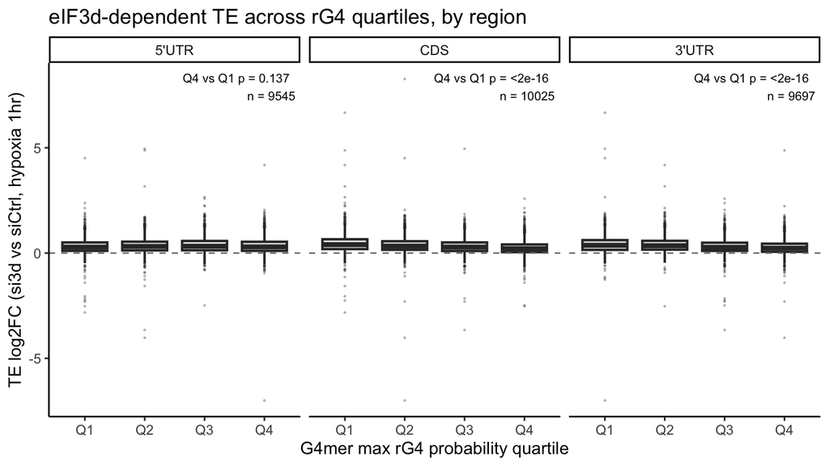

```r
p_quart <- ggplot(dat_q, aes(x = g4_quartile, y = te_lfc)) +
  geom_boxplot(outlier.size = 0.3, outlier.alpha = 0.25, fill = "grey90",
               linewidth = 0.8) +
  geom_hline(yintercept = 0, linetype = "dashed", colour = "grey50") +
  facet_wrap(~ region_lab) +
  geom_text(data = q_tests, inherit.aes = FALSE,
            aes(x = Inf, y = Inf,
                label = sprintf("Q4 vs Q1 p = %s\nn = %d",
                                format.pval(p, digits = 3), n)),
            hjust = 1.1, vjust = 1.4, size = 3) +
  labs(
    x = "G4mer max rG4 probability quartile",
    y = "TE log2FC (si3d vs siCtrl, hypoxia 1hr)",
    title = "eIF3d-dependent TE across rG4 quartiles, by region"
  ) +
  theme_classic(base_size = 12)

print(p_quart)
```

```r
ggsave(here("plots", "01u_g4mer_te_by_quartile_all_regions.pdf"),
       p_quart, width = 8, height = 4.5)
```

## G4mer Score by Gene Group, per Region

```r
promotes <- read_csv(here("output", "genesets", "hypoxia_3d_promotes_TE_1hr_lfc0.5.csv"),
                     show_col_types = FALSE) %>%
  pull(ensembl_gene) %>% unique()

neg_pool <- read_csv(here("output", "predictive_modeling", "negative_control_genes.csv"),
                     show_col_types = FALSE) %>%
  mutate(gene_id_clean = sub("\\..*", "", gene_id)) %>%
  pull(gene_id_clean) %>% unique()

set.seed(9)
dat_grp <- dat_long %>%
  mutate(group = case_when(
    gene_id_clean %in% promotes ~ "eIF3d hypoxia promotes",
    gene_id_clean %in% neg_pool ~ "Negative control",
    TRUE                        ~ "All other genes"
  )) %>%
  mutate(group = factor(group, levels = names(group_colors)),
         region_lab = factor(region_labels[region], levels = region_labels))

group_tests <- dat_grp %>%
  filter(group != "All other genes") %>%
  droplevels() %>%
  group_by(region_lab) %>%
  group_modify(function(d, key) {
    unmatched <- wilcox.test(g4mer_max ~ group, data = d)

    # Length-decile matched: equal n per group within each length bin
    d2 <- d %>% mutate(bin = ntile(log2_region_length, 10))
    matched <- d2 %>% group_by(bin) %>% group_modify(function(x, ...) {
      k <- min(sum(x$group == "eIF3d hypoxia promotes"),
               sum(x$group == "Negative control"))
      if (k < 5) return(x[0, ])
      bind_rows(
        slice_sample(filter(x, group == "eIF3d hypoxia promotes"), n = k),
        slice_sample(filter(x, group == "Negative control"), n = k)
      )
    }) %>% ungroup()

    tibble(
      n_pos       = sum(d$group == "eIF3d hypoxia promotes"),
      n_neg       = sum(d$group == "Negative control"),
      med_pos     = median(d$g4mer_max[d$group == "eIF3d hypoxia promotes"]),
      med_neg     = median(d$g4mer_max[d$group == "Negative control"]),
      p_unmatched = unmatched$p.value,
      n_matched   = sum(matched$group == "eIF3d hypoxia promotes"),
      p_matched   = wilcox.test(g4mer_max ~ group, data = matched)$p.value
    )
  }) %>% ungroup()

print(group_tests %>%
        mutate(across(c(med_pos, med_neg), ~ round(.x, 4)),
               across(starts_with("p_"), ~ format.pval(.x, digits = 3))),
      width = Inf)
```

```
## # A tibble: 3 × 8
##   region_lab n_pos n_neg med_pos med_neg p_unmatched n_matched p_matched
##   <fct>      <int> <int>   <dbl>   <dbl> <chr>           <int> <chr>
## 1 5'UTR       1338  2595  0.257    0.149 1.96e-06         1338 0.046326
## 2 CDS         1393  2748  0.0804   0.414 < 2e-16          1340 9.98e-14
## 3 3'UTR       1358  2659  0.125    0.324 < 2e-16          1358 0.000193
```

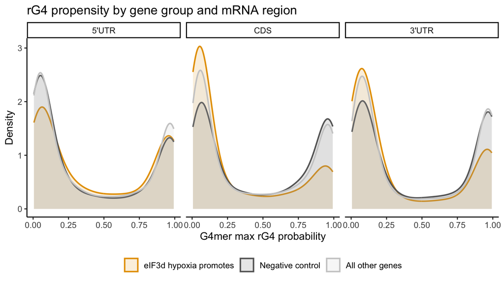

```r
p_group <- ggplot(dat_grp, aes(x = g4mer_max, fill = group, colour = group)) +
  geom_density(alpha = 0.15, linewidth = 0.8) +
  facet_wrap(~ region_lab) +
  scale_fill_manual(values = group_colors) +
  scale_colour_manual(values = group_colors) +
  labs(
    x = "G4mer max rG4 probability",
    y = "Density",
    title = "rG4 propensity by gene group and mRNA region",
    fill = NULL, colour = NULL
  ) +
  theme_classic(base_size = 12) +
  theme(legend.position = "bottom")

print(p_group)
```

```r
ggsave(here("plots", "01u_g4mer_by_gene_group_all_regions.pdf"),
       p_group, width = 8, height = 4.5)
```

## Cross-Region Comparison at Matched Stride

```r
# Uses g4mer_max_harmonized so all three regions are scored at stride 20
harmonized_summary <- dat_long %>%
  group_by(region) %>%
  summarise(
    n          = dplyr::n(),
    median_max = median(g4mer_max_harmonized),
    pct_above_half = 100 * mean(g4mer_max_harmonized >= 0.5),
    .groups = "drop"
  ) %>%
  mutate(region = region_labels[region])
print(harmonized_summary)
```

```
## # A tibble: 3 × 4
##   region     n median_max pct_above_half
##   <chr>  <int>      <dbl>          <dbl>
## 1 CDS    10025      0.227           41.6
## 2 3'UTR   9697      0.205           42.2
## 3 5'UTR   9545      0.152           36.0
```

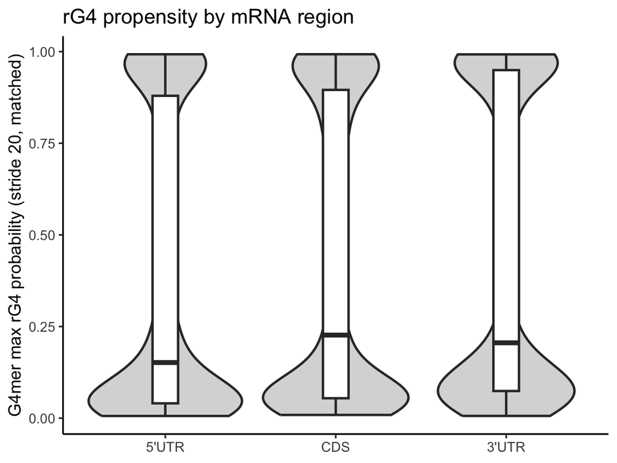

```r
p_cross <- dat_long %>%
  mutate(region_lab = factor(region_labels[region], levels = region_labels)) %>%
  ggplot(aes(x = region_lab, y = g4mer_max_harmonized)) +
  geom_violin(fill = "grey85", linewidth = 0.8) +
  geom_boxplot(width = 0.15, outlier.shape = NA, linewidth = 0.8) +
  labs(
    x = NULL,
    y = "G4mer max rG4 probability (stride 20, matched)",
    title = "rG4 propensity by mRNA region"
  ) +
  theme_classic(base_size = 12)

print(p_cross)
```

```r
ggsave(here("plots", "01u_g4mer_max_by_region.pdf"), p_cross, width = 6, height = 4.5)
```

## Summary

```r
cat("=== G4mer rG4 vs eIF3d hypoxia TE (1hr), all regions ===\n\n")
```

```
## === G4mer rG4 vs eIF3d hypoxia TE (1hr), all regions ===
```

```r
for (r in regions) {
  s <- region_stats %>% filter(region == r)
  q <- q_tests %>% filter(region_lab == region_labels[r])
  g <- group_tests %>% filter(region_lab == region_labels[r])
  cat(sprintf("%-6s n = %5d | raw rho = %+.4f (p = %-9s) | partial rho = %+.4f (p = %-9s)\n",
              region_labels[r], s$n, s$rho_raw, format.pval(s$p_raw, digits = 2),
              s$rho_partial, format.pval(s$p_partial, digits = 2)))
  cat(sprintf("        Q4-Q1 median TE diff = %+.4f (p = %s)\n",
              q$diff_med, format.pval(q$p, digits = 2)))
  cat(sprintf("        promoted vs neg ctrl: unmatched p = %-9s | length-matched p = %s\n",
              format.pval(g$p_unmatched, digits = 2),
              format.pval(g$p_matched, digits = 2)))
  cat(sprintf("        GC%% vs te_lfc rho = %+.4f (for comparison)\n\n", s$rho_gc_te))
}
```

```
## 5'UTR  n =  9545 | raw rho = +0.0174 (p = 0.089    ) | partial rho = +0.0319 (p = 0.0018   )
##         Q4-Q1 median TE diff = +0.0136 (p = 0.14)
##         promoted vs neg ctrl: unmatched p = 2e-06     | length-matched p = 0.046
##         GC% vs te_lfc rho = -0.1514 (for comparison)
##
## CDS    n = 10025 | raw rho = -0.2206 (p = <2e-16   ) | partial rho = -0.0056 (p = 0.58     )
##         Q4-Q1 median TE diff = -0.1930 (p = <2e-16)
##         promoted vs neg ctrl: unmatched p = <2e-16    | length-matched p = 1e-13
##         GC% vs te_lfc rho = -0.3618 (for comparison)
##
## 3'UTR  n =  9697 | raw rho = -0.1548 (p = <2e-16   ) | partial rho = -0.0166 (p = 0.1      )
##         Q4-Q1 median TE diff = -0.1350 (p = <2e-16)
##         promoted vs neg ctrl: unmatched p = <2e-16    | length-matched p = 0.00019
##         GC% vs te_lfc rho = -0.2637 (for comparison)
```

```r
cat("Project fold-change standard is 0.5; compare the Q4-Q1 differences against it.\n")
```

```
## Project fold-change standard is 0.5; compare the Q4-Q1 differences against it.
```